# BrExit Survey Data Exploration

## Week 3 Report

### Background:

British Election study: Examine the support of secessionist movements among first and secod generation immigrants. The data consists of answers to survey questions asked in different waves (total of 13), from 2014 - 2018.

## Goals of previous week:

### Success

- Step 1. To visualize the general “opinion landscape” on leave/stay in the EU for each wave of survey.
- Step 2. Further investigate the difference between sub demographic groups:
  - Age_group
  - Education
  - Social Economic Status (?)
  - Urban rural
  - Party ID
  - Political philosophy
  - Conservative -> break from EU
  - Pro-labour -> stay in EU

### Sweet

- Create condensed data set to work with.
- Figure out accumulative weight.

### Amazing

- Investigate the general “opinion landscape” on leave/stay in the EU for intersection of waves.

### Note:

Calculation of weights: # of weights that said yes/ # of weights that said yes + said no

# Step One:

## Collect general stay percent from each wave

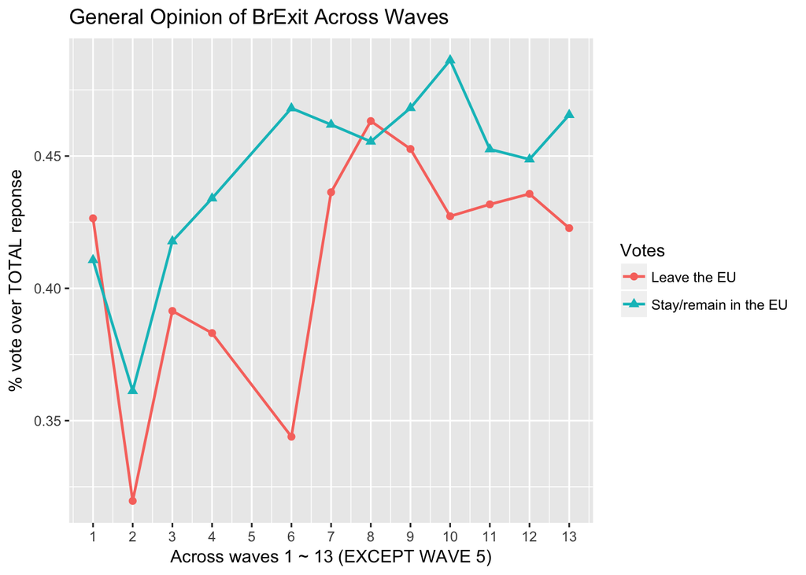

# Step Two: Look at demographic subgroups

## Step 2.1: create new dataset

The original dataset is person-level. It looks like:

```
##   id country wave1 wave2 wave3 wave4 wave5 wave6 wave7 wave8 wave9 wave10
## 1  1 England     1     1     0     1     1     1     1     1     1      1
## 2  2 England     1     0     1     1     1     1     1     1     1      1
## 3  3 England     1     1     1     1     1     1     1     0     0      1
## 4  4 England     1     1     0     0     0     0     0     0     0      0
## 5  5 England     1     1     0     0     0     0     0     0     0      0
## 6  6   Wales     1     1     1     1     1     1     1     0     0      0
##   wave11 wave12 wave13 wt_core_W3 wt_core_W4 wt_core_W5
## 1      0      0      0         NA  0.8018927  0.8257872
## 2      1      1      1         NA  0.9589404  0.9073402
## 3      1      1      1  2.8824487  2.3166203  2.3884541
## 4      0      0      0         NA         NA         NA
## 5      0      0      0         NA         NA         NA
## 6      1      0      1  0.7210248  0.8878899  0.9799274
##             euRefVoteW1           euRefVoteW2           euRefVoteW3
## 1          Leave the EU                  <NA>                  <NA>
## 2            Don't know                  <NA>            Don't know
## 3 Stay/remain in the EU Stay/remain in the EU Stay/remain in the EU
## 4          Leave the EU                  <NA>                  <NA>
## 5 Stay/remain in the EU          Leave the EU                  <NA>
## 6            Don't know                  <NA>          Leave the EU
##             euRefVoteW4           euRefVoteW6
## 1          Leave the EU          Leave the EU
## 2            Don't know Stay/remain in the EU
## 3 Stay/remain in the EU Stay/remain in the EU
## 4                  <NA>                  <NA>
## 5                  <NA>                  <NA>
## 6 Stay/remain in the EU            Don't know
```

After manipulation, we get a wave-level data that looks like:

```
##   id        wt         vote wave country ageW1 countryOfBirth
## 1  1 0.8509580 Leave the EU    1 England    58        England
## 2  1        NA         <NA>    2 England    58        England
## 3  1 0.8018927 Leave the EU    4 England    58        England
## 4  1 0.8152761 Leave the EU    6 England    58        England
## 5  1 0.8223353 Leave the EU    7 England    58        England
## 6  1        NA Leave the EU    8 England    58        England
```

## Step 2.2: graphs

### Country of origin

“For each demographic subgroup, how does the stay/leave opinion change over time?”

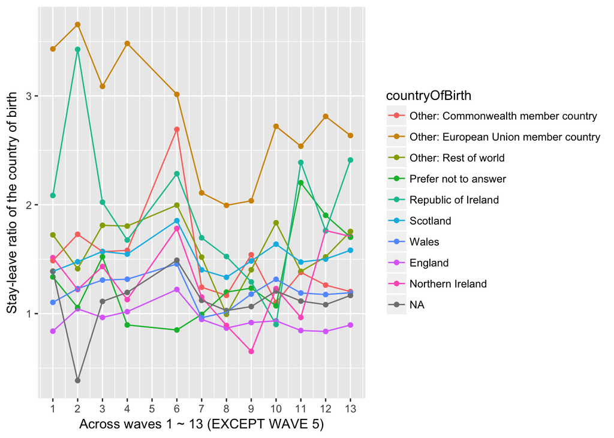

### Need further investigation:

**Note: wierd drop in England origin**

### Examine opinion change of people with English origin

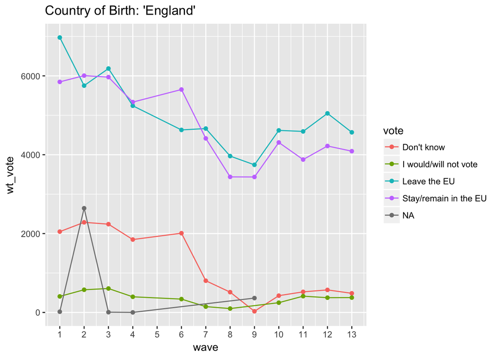

[figure not shown]

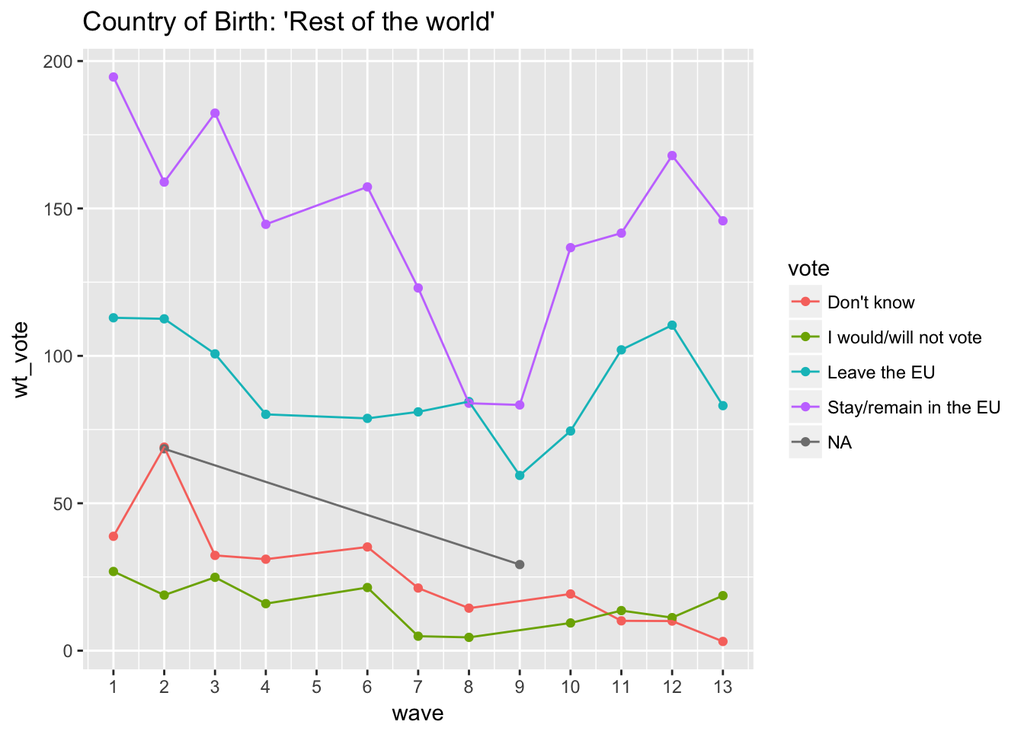

### Look into total demographic change (country of origin)

** Very wierd **

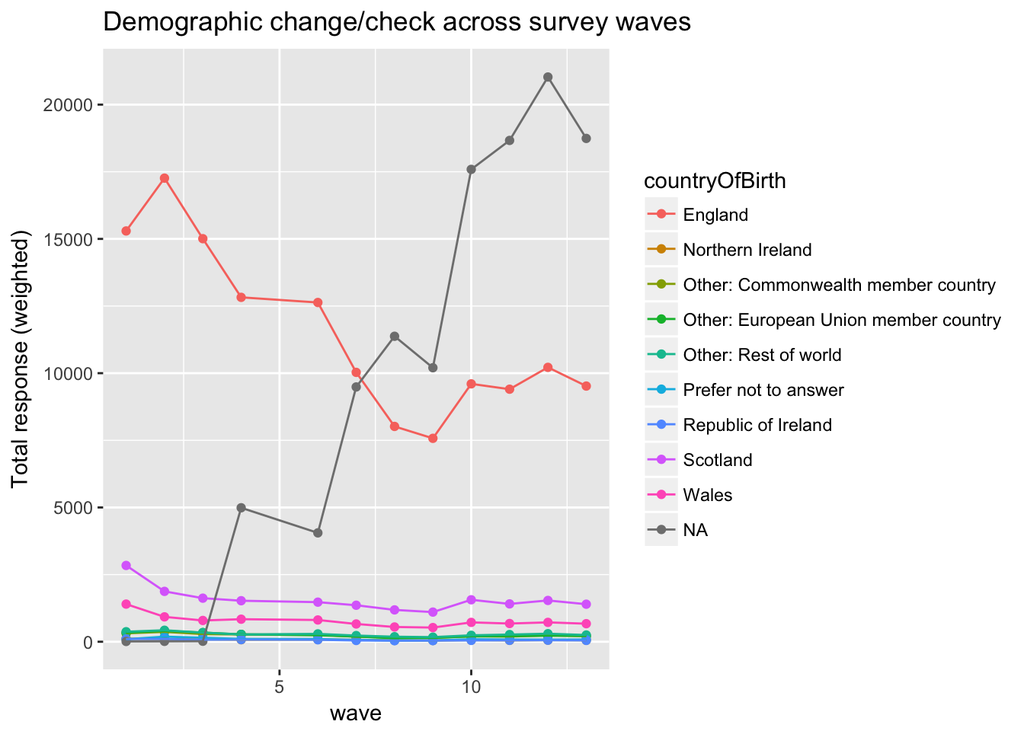

### Next time:

### Opinion divide within each group of country origin

## Next Goal

- Mark 3 critical events
- Continuous waves (1~13) ** Determine the most continuous waves (balance sample size)
- Other demographic groups

# TODO:

- missing vote for wave 5 ??? => check original dataset
- find wt_new_w10